# Лабораторная работа 2

Результат лабораторной работы − отчет. Мы предпочитаем принимать отчеты в формате ноутбуков Jupyter (ipynb-файл). Постарайтесь сделать ваш отчет интересным рассказом, последовательно отвечающим на вопросы из заданий, а также подкреплённый грамотной визуализацией. Помимо ответов на вопросы, в отчете так же должен быть код, однако чем меньше кода, тем лучше всем: нам − меньше проверять, вам — проще найти ошибку или дополнить эксперимент. При проверке оценивается четкость ответов на вопросы, аккуратность отчета, кода и графиков.

## Оценивание и штрафы

- Каждая из задач имеет определенную «стоимость» (указана в скобках около задачи)
- Максимально допустимая оценка за работу — 15 баллов
- Сдавать задание после указанного срока сдачи нельзя
- «Похожие» решения считаются плагиатом и все задействованные студенты (в том числе те, у кого списали) не могут получить за него больше 0 баллов и понижают свою карму
- Если вы нашли решение какого-то из заданий в открытом источнике, необходимо прислать ссылку на этот источник (скорее всего вы будете не единственным, кто это нашел, поэтому, чтобы исключить подозрение в плагиате, необходима ссылка на источник)
- Не оцениваются задания с удалёнными формулировкам
- Не оценивается лабораторная работа целиком, если она была выложена в открытый источник

## Прорабатываемые темы

- Деревья
- Лес
- Бустинг

## Данные

Из официального блога Яндекса [известно,](https://yandex.ru/blog/company/meteum-2-0-ili-pochemu-yandeks-pogoda-sprashivaet-vas-o-dozhde) что технология предсказания погоды Метеум 2.0 опирается на Catboost.

Там же говорится, о том, что в качестве признаков используются данные от метеомоделей и дополнительные признаки, например, `высота солнца над горизонтом` или `удалённость от водоёма`.

Этим летом Яндекс выложил в свободный доступ погодный датасет. В данной лабораторной работе мы будем пытаться сделать свой прогноз погоды, основываясь на этих данных.

Лицензия на данные доступна [тут](https://github.com/yandex-research/shifts#license).

### Метеомодели

Что из себя представляет прогноз метеомодели? Фактически, это четырёхмерный тензор.

- Две компоненты -- это широта и долгота. У каждого поставщика прогнозов свои шаги сетки по широте и долготе;
- Вырожденное измерение, которое содержит только одно значение -- время начального состояния атмосферы, с которого будет начато физическое моделирование;
- Последнее измерение - время, на которое сделан прогноз. Каждый поставщик таже имеет свои сетки, но обычно не чаще одного прогноза в час.

Для хранения таких данных был разработан формат файлов https://en.wikipedia.org/wiki/GRIB

Например, такие данные для модели GFS можно скачать с сайта https://www.ncei.noaa.gov/products/weather-climate-models/global-forecast

### Признаки

Из первых уст про признаки можно узнать из [видео Лены Волжиной.](https://youtu.be/ECALEJ79KHg?t=578)

Их источники можно разделить на следующие группы

- Прогноз глобальных метеомоделей. В выгруженных данных это модели CMC и GFS
  - признаки, которые начинаются с `cmc_`
  - признаки, которые начинаются с `gfs_`
- Прогнозы от региональной модели WRF
  - признаки, которые начинаются с `wrf_`
- Климатические данные (за 40 лет наблюдений)
  - признаки, которые начинаются с `climate_`
- Прочие признаки
  - 'sun_elevation' -- та самая высота солнца над горизонтом.
  - 'topography_bathymetry'

Признаки cmc имеют в своём имени 4 числа, которые кодируют физическую величину. Последнее значение -- это высота, на которой величина вычислена.

Признаки gfs и wrf имеют человеко-читаемые названия.

Еще есть технические атрибуты прогноза поставщика:

- `_available` -- был ли доступен поставщик при прогнозе
- `_horizon_h` -- каковым горизонтом для модели поставщика была временная отметка, на которую meteum рассчитвал прогноз.
- `_next` -- это значение следущего прогноза данного поставщика для данной точки.

Кроме того, есть еще признаки, комбинирующие выше описанные, например

- _grad -- это разница разница между обычным и _next прогнозом температуры.

Вот рисунок, который поможет разобраться с этими терминами:

[figure not shown]

### Целевые переменные

- fact_temperature -- температура в данной точке (точка описывается парой координат 'fact_latitude', 'fact_longitude' и временной отметкой 'fact_time' )
- fact_cwsm_class -- код облачности и осадков

[figure not shown]

### Факты

Источником истинных меток в задачах прогнозирования погоды служат данные с метеостанций. Каждая метеостанция имеет свои географические кординаты, а также свою частоту, с которой она замеряет погоду. Некоторые метеостанции замеряют ее лишь 8 раз в день при помощи специалистов-метеорологов. Некоторые являются автоматическими и имеют большую частоту потока фактических показателей.

### Как был собран dataset

Каждое из фактических предсказаний могло быть предсказано с разными заблаговременностями.

Было составлено декартово произведение следующих множеств (см. рисунок выше)

- (время факта, координата факта)
- (время составления прогноза)
- (самый свежий прогноз от поставщика, доступный к моменту составления прогноза на время, ближайшее ко времени факта)

Оно было равномерно просемлировано, чтобы его размер стал обозримым.

```python
import numpy as np
```

## Знакомство с данными

Для уменьшения количества данных, возьмем только кусок за сентябрь 2018 года

```python
path_csv_2018_09 = 'data_2/train_2018_09.csv'
path_csv_2018_10 = 'data_2/train_2018_10.csv'
path_csv_2018_11 = 'data_2/train_2018_11.csv'
```

```python
import pandas as pd
import matplotlib.pyplot as plt
```

```python
train_2018_09 = pd.read_csv(path_csv_2018_09)
train_2018_10 = pd.read_csv(path_csv_2018_10)
train_2018_11 = pd.read_csv(path_csv_2018_11)
```

```python
fact_columns = [
 'fact_time',
 'fact_latitude',
 'fact_longitude',
 'fact_temperature',
 'fact_cwsm_class'
]
```

```python
other_columns = [
 'topography_bathymetry',
 'sun_elevation',
]

climate_columns = [
 'climate_temperature',
 'climate_pressure',
]

climat_zone_column = 'climate'
```

```python
cmc_columns = [
 'cmc_0_0_0_1000',
 'cmc_0_0_0_2_grad',
 'cmc_0_0_0_2_interpolated',
 'cmc_0_0_0_2_next',
 'cmc_0_0_0_2',
 'cmc_0_0_0_500',
 'cmc_0_0_0_700',
 'cmc_0_0_0_850',
 'cmc_0_0_0_925',
 'cmc_0_0_6_2',
 'cmc_0_0_7_1000',
 'cmc_0_0_7_2',
 'cmc_0_0_7_500',
 'cmc_0_0_7_700',
 'cmc_0_0_7_850',
 'cmc_0_0_7_925',
 'cmc_0_1_0_0',
 'cmc_0_1_11_0',
 'cmc_0_1_65_0',
 'cmc_0_1_66_0',
 'cmc_0_1_67_0',
 'cmc_0_1_68_0',
 'cmc_0_1_7_0',
 'cmc_0_2_2_10',
 'cmc_0_2_2_1000',
 'cmc_0_2_2_500',
 'cmc_0_2_2_700',
 'cmc_0_2_2_850',
 'cmc_0_2_2_925',
 'cmc_0_2_3_10',
 'cmc_0_2_3_1000',
 'cmc_0_2_3_500',
 'cmc_0_2_3_700',
 'cmc_0_2_3_850',
 'cmc_0_2_3_925',
 'cmc_0_3_0_0',
 'cmc_0_3_0_0_next',
 'cmc_0_3_1_0',
 'cmc_0_3_5_1000',
 'cmc_0_3_5_500',
 'cmc_0_3_5_700',
 'cmc_0_3_5_850',
 'cmc_0_3_5_925',
 'cmc_0_6_1_0',
 'cmc_available',
 'cmc_horizon_h',
 'cmc_precipitations',
 'cmc_timedelta_s',
 'cmc_0_1_65_0_grad',
 'cmc_0_1_65_0_next',
 'cmc_0_1_66_0_grad',
 'cmc_0_1_66_0_next',
 'cmc_0_1_67_0_grad',
 'cmc_0_1_67_0_next',
 'cmc_0_1_68_0_grad',
 'cmc_0_1_68_0_next',
]
```

```python
gfs_columns = [
 'gfs_2m_dewpoint',
 'gfs_a_vorticity',
 'gfs_available',
 'gfs_cloudness',
 'gfs_clouds_sea',
 'gfs_horizon_h',
 'gfs_humidity',
 'gfs_precipitable_water',
 'gfs_precipitations',
 'gfs_pressure',
 'gfs_r_velocity',
 'gfs_soil_temperature',
 'gfs_soil_temperature_available',
 'gfs_temperature_10000',
 'gfs_temperature_15000',
 'gfs_temperature_20000',
 'gfs_temperature_25000',
 'gfs_temperature_30000',
 'gfs_temperature_35000',
 'gfs_temperature_40000',
 'gfs_temperature_45000',
 'gfs_temperature_5000',
 'gfs_temperature_50000',
 'gfs_temperature_55000',
 'gfs_temperature_60000',
 'gfs_temperature_65000',
 'gfs_temperature_7000',
 'gfs_temperature_70000',
 'gfs_temperature_75000',
 'gfs_temperature_80000',
 'gfs_temperature_85000',
 'gfs_temperature_90000',
 'gfs_temperature_92500',
 'gfs_temperature_95000',
 'gfs_temperature_97500',
 'gfs_temperature_sea',
 'gfs_temperature_sea_grad',
 'gfs_temperature_sea_interpolated',
 'gfs_temperature_sea_next',
 'gfs_timedelta_s',
 'gfs_total_clouds_cover_high',
 'gfs_total_clouds_cover_low',
 'gfs_total_clouds_cover_middle',
 'gfs_u_wind',
 'gfs_v_wind',
 'gfs_wind_speed',
 'gfs_2m_dewpoint_grad',
 'gfs_2m_dewpoint_next',
 'gfs_total_clouds_cover_low_grad',
 'gfs_total_clouds_cover_low_next'
]
```

```python
wrf_columns = [
 'wrf_available',
 'wrf_t2',
 'wrf_t2_next',
 'wrf_psfc',
 'wrf_rh2',
 'wrf_wind_u',
 'wrf_wind_v',
 'wrf_rain',
 'wrf_snow',
 'wrf_graupel',
 'wrf_hail',
 'wrf_t2_interpolated',
 'wrf_t2_grad',
]
```

Мы будем рассматривать задачи двух типов

- Задачу регрессии предсказания температуры (колонка fact_temperature)
- Задачу классификации -- предсказание кода облачности и осадков (колонка fact_cwsm_class)

Рассмотрим, как метки этих задач расположены на "карте мира":

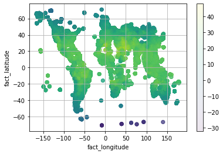

```python
plt.scatter(
    train_2018_09.fact_longitude,
    train_2018_09.fact_latitude,
    c= train_2018_09.fact_temperature,
    alpha=0.1
)
plt.ylabel("fact_latitude")
plt.xlabel("fact_longitude")
plt.colorbar()
plt.grid()
```

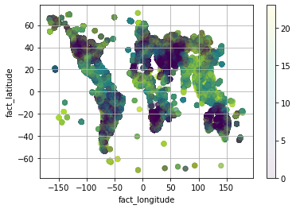

```python
plt.scatter(
   train_2018_09.fact_longitude,
   train_2018_09.fact_latitude,
   c= train_2018_09.fact_cwsm_class,
   alpha=0.1
)
plt.ylabel("fact_latitude")
plt.xlabel("fact_longitude")
plt.colorbar()
plt.grid()
```

### Задание 1. Исследование данных (1 балл)

Проведите исследовательский анализ данных.

Задача: понять взаимосвязи между откликами fact_temperature и fact_cwsm_class и признаками

Для начала посмотрим, как коррелируют стобцы **fact_temperature**, **fact_cwsm_class** c остальными данными в датасете. Интересные колонки, которые являются предсказаниями моделей поставщиков отмечены синим. Топографические данные, положение солнца, а также исторические наблюдения **climate_** отмечены оранжевым.

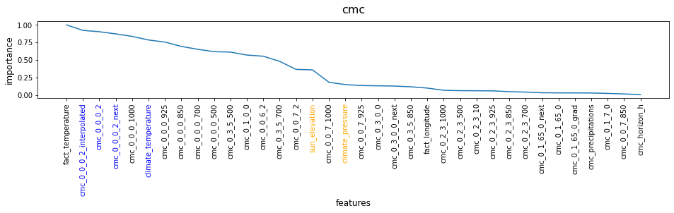

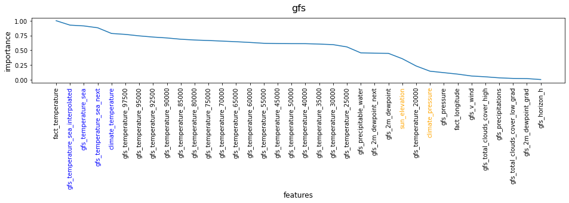

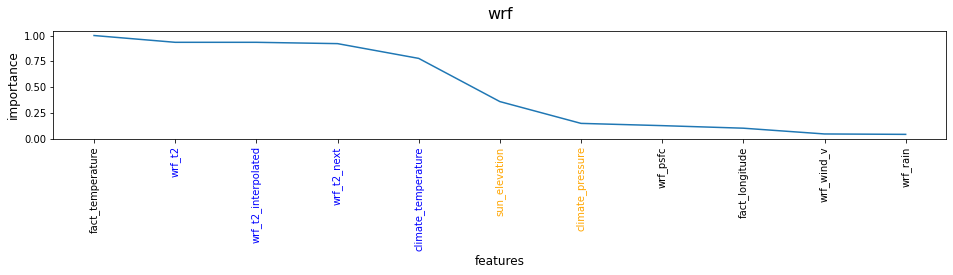

```python
interesting_coloumns = ['climate_temperature', 'cmc_0_0_0_2_interpolated', 'cmc_0_0_0_2_next', 'cmc_0_0_0_2',
                               'gfs_temperature_sea', 'gfs_temperature_sea_interpolated', 'gfs_temperature_sea_next',
                              'wrf_t2', 'wrf_t2_next', 'wrf_t2_interpolated']

def paint_tick(ax, indexes):
    ax.xaxis.set_ticks(indexes)
    ax.set_xticklabels(indexes)
    for tick in ax.xaxis.get_ticklabels():
        if tick.get_text() in interesting_coloumns:
            tick.set_color('blue')
        elif tick.get_text() in other_columns + climate_columns:
            tick.set_color('orange')

def corr_with_temp(columns_name: str):
    col = [cmc_columns, gfs_columns, wrf_columns][['cmc', 'gfs', 'wrf'].index(columns_name)]
    columns = fact_columns + other_columns + climate_columns + col
    df = train_2018_09.loc[:, columns]

    if columns_name == 'cmc':
        df = df.loc[df.cmc_available == 1]
    elif columns_name == 'gfs':
        df = df.loc[df.gfs_available == 1]
    else:
        df = df.loc[df.wrf_available == 1]

    temp_corr = df.corrwith(df.fact_temperature)
    temp_coor_over_zero = temp_corr[temp_corr > 0].sort_values(ascending=False)

    fig = plt.figure(figsize=(16, 2))
    ax = fig.add_subplot(111)
    ax.plot(temp_coor_over_zero.index, temp_coor_over_zero)
    plt.title(columns_name, fontsize=16, y=1.05)
    plt.xlabel("features", fontsize=12)
    plt.ylabel("importance", fontsize=12)
    plt.xticks(rotation=90)

    paint_tick(ax, temp_coor_over_zero.index)

    plt.show()

for columns in ['cmc', 'gfs', 'wrf']:
    corr_with_temp(columns)
```

Видим, что фактическая температура на момент предсказания сильнее всего коррелирует с предсказаниями моделей поставщиков. Следом по важности идет историческая информация о температуре. В модели **gfs** можно заметить, что колонки с температурой **gfs*temterature*** располагаются друг за другом по возрастанию по мере приближения к моменту фактического замера. Заметно и влияние положения солнца, давления, скорости ветра и фактической долготы. В модели **wrf** наибольший вклад вносят именно предсказания этого поставщика, остальные колонки, скорее всего, будут больше влиять на предсказания осадков. В модели **cmc** столбцы **cmc_0_0*0***, соответствующие температуре при определенном давлении, значительно коррелируют с температурой. Также в первых двух моделях заметно влияние точки росы (dew point).

Для установления влияния признаков на **fact_cwsm_class** я разбил датасет по облачности $-\textit{ }cloudy \in \{0, 0.5, 1\}$.

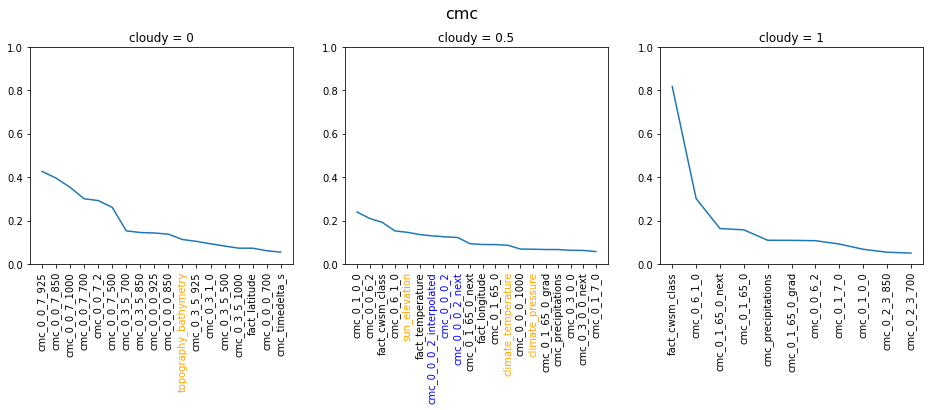

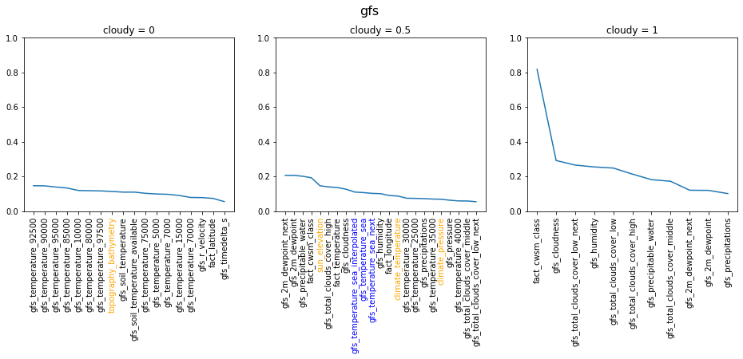

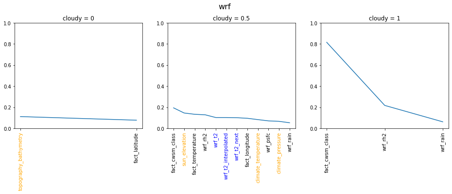

```python
IMPORTANCE = 0.05

def draw_cwsm_plot(ax, cwsm_coor, cloudy):
    ax.plot(cwsm_coor.index, cwsm_coor)
    ax.set_title('cloudy = {}'.format(cloudy))
    ax.set_ylim(0, 1)
    paint_tick(ax, cwsm_coor.index)
    plt.setp(ax.xaxis.get_majorticklabels(), rotation=90)

def corr_with_cwsm(columns_name: str):
    col = [cmc_columns, gfs_columns, wrf_columns][['cmc', 'gfs', 'wrf'].index(columns_name)]
    columns = fact_columns + other_columns + climate_columns + col
    df = train_2018_09.loc[:, columns]

    if columns_name == 'cmc':
        df = df.loc[df.cmc_available == 1]
    elif columns_name == 'gfs':
        df = df.loc[df.gfs_available == 1]
    else:
        df = df.loc[df.wrf_available == 1]

    cwsm_corr_0 = df.corrwith(df.fact_cwsm_class == 0)
    cwsm_coor_over_zero_0 = cwsm_corr_0[cwsm_corr_0 > IMPORTANCE].sort_values(ascending=False)
    cwsm_corr_10 = df.corrwith((10 <= df.fact_cwsm_class) & (df.fact_cwsm_class < 20))
    cwsm_coor_over_zero_10 = cwsm_corr_10[cwsm_corr_10 > IMPORTANCE].sort_values(ascending=False)
    cwsm_corr_20 = df.corrwith(df.fact_cwsm_class >= 20)
    cwsm_coor_over_zero_20 = cwsm_corr_20[cwsm_corr_20 > IMPORTANCE].sort_values(ascending=False)

    f, ax = plt.subplots(1, 3, figsize=(16, 4))
    f.suptitle(columns_name, fontsize=16, y=1.02)

    draw_cwsm_plot(ax[0], cwsm_coor_over_zero_0, 0)
    draw_cwsm_plot(ax[1], cwsm_coor_over_zero_10, 0.5)
    draw_cwsm_plot(ax[2], cwsm_coor_over_zero_20, 1)

    plt.show()

for columns in ['cmc', 'gfs', 'wrf']:
    corr_with_cwsm(columns)
```

*cloudy = 0*

В модели **cmc** параметр **cmc_0_0_7** соответствует точке росы, которая сильнее всего влияет отсутствие осадков. Также просолеживается влияние и атмосферного давления **cmc_0_3_5**. В модели **gfs** на отсутствие осадков примерно в раной степени сказываются различные показатели температуры. Модель **wrf** для предсказания отсутсвия осадков ничего не предлагает.

*cloudy > 0*

При cloudy=1 в модели **cmc** самыми важными признаками являются: облачность, информация о скоплении дождя, осадки, точка росы. Похожая ситуация и с поставщиком **gfs**. В модели **wrf** оказываются важными лишь показания влажности и скопления дождя.

## Часть 1

Начнем с более простой задачи регрессии.

Как обычно, сначало вычислим набор тривиальных baseline решений. Будем использовать 2 метрики качества

- RMSE -- основная метрика
- Долю отклонений от факта на 2 градуса -- вспомогательная метрика

### Задание 2. Baseline решение (0.5 балла)

Построить baseline решения и вычислить метрики на периоде 2018_09:

- климат (climate_temperature)
- Предсказание поставщиков
  - cmc
    - 'cmc_0_0_0_2_interpolated'
    - 'cmc_0_0_0_2_next'
    - 'cmc_0_0_0_2'
  - gfs
    - 'gfs_temperature_sea'
    - 'gfs_temperature_sea_interpolated'
    - 'gfs_temperature_sea_next'
  - wrf
    - 'wrf_t2'
    - 'wrf_t2_next'
    - 'wrf_t2_interpolated'
- Dummy Regressor
  - https://scikit-learn.org/stable/modules/generated/sklearn.dummy.DummyRegressor.html
    - обучать на 2018_09, тетсировать на 2018_10

```python
from sklearn.metrics import mean_squared_error, make_scorer

rmse_score = make_scorer(mean_squared_error, squared=False, greater_is_better=False)

def two_gradus_score(y_true, y_pred):
    x, y = np.array(y_pred), np.array(y_true)
    return ((x - 2 <= y) & (y <= x + 2)).sum() / np.array(y_true).size
```

Для начала настроим основную и вспомогательную метрики. В дальнейшем оценку на отклонение в два градуса я буду называть *TGS*.

```python
from sklearn.dummy import DummyRegressor

scores = pd.DataFrame(columns=['rmse', 'tgs'], index=interesting_coloumns)

def dummy_check(prediction: str):
    df = train_2018_09[['fact_temperature', 'cmc_available', 'gfs_available', 'wrf_available', prediction]]
    df2 = train_2018_10[['fact_temperature', 'cmc_available', 'gfs_available', 'wrf_available', prediction]]

    if prediction.startswith('cmc'):
        df = df.loc[df.cmc_available == 1]
        df2 = df2.loc[df2.cmc_available == 1]
    elif prediction.startswith('gfs'):
        df = df.loc[df.gfs_available == 1]
        df2 = df2.loc[df2.gfs_available == 1]
    else:
        df = df.loc[df.wrf_available == 1]
        df2 = df2.loc[df2.wrf_available == 1]

    dummy = DummyRegressor().fit(df[prediction], df.fact_temperature)
    tgs = two_gradus_score(df2.fact_temperature, dummy.predict(df2[prediction]))
    rmse = mean_squared_error(df2.fact_temperature, dummy.predict(df2[prediction]), squared=False)
    scores.loc[prediction] = [rmse, tgs]

for prediction in interesting_coloumns:
    dummy_check(prediction)

scores
```

|  | rmse | tgs |
| --- | --- | --- |
| climate_temperature | 9.031042 | 0.174578 |
| cmc_0_0_0_2_interpolated | 9.065952 | 0.17422 |
| cmc_0_0_0_2_next | 9.065952 | 0.17422 |
| cmc_0_0_0_2 | 9.065952 | 0.17422 |
| gfs_temperature_sea | 9.063705 | 0.17421 |
| gfs_temperature_sea_interpolated | 9.063705 | 0.17421 |
| gfs_temperature_sea_next | 9.063705 | 0.17421 |
| wrf_t2 | 9.031042 | 0.174578 |
| wrf_t2_next | 9.031042 | 0.174578 |
| wrf_t2_interpolated | 9.031042 | 0.174578 |

Видим достаточно плохие показатели среднеквадратического отклонения и двухградусной метрики при использовании DummyRegressor.

### Задание 3. Решающее дерево (0.5 балла)

Подобрать лучшее дерево решений на валидации. Понять, сколько в нём листов, и как долго оно обучается.

- обучающее множество пусть будет 2018_09, а валидационное -- 2018_10

```python
from sklearn.tree import DecisionTreeRegressor
from sklearn.model_selection import GridSearchCV
from sklearn.preprocessing import OneHotEncoder

#бинаризируем мультиклассовый столбец climate
train_2018_09_climate = pd.DataFrame(train_2018_09.climate)
ohe = OneHotEncoder(handle_unknown='ignore').fit(train_2018_09_climate)

climate_ohe9 = pd.DataFrame.sparse.from_spmatrix(
    ohe.transform(train_2018_09_climate), columns=ohe.categories_[0]).sparse.to_dense()
climate_ohe10 = pd.DataFrame.sparse.from_spmatrix(
    ohe.transform(pd.DataFrame(train_2018_10.climate)), columns=ohe.categories_[0]).sparse.to_dense()
climate_ohe11 = pd.DataFrame.sparse.from_spmatrix(
    ohe.transform(pd.DataFrame(train_2018_11.climate)), columns=ohe.categories_[0]).sparse.to_dense()

regressor_features = other_columns + climate_columns

df_train = pd.concat([train_2018_09[regressor_features], climate_ohe9], axis=1)
df_valid = pd.concat([train_2018_10[regressor_features], climate_ohe10], axis=1)
```

Для оценки качества информации, предоставляемой каждым поставщиком, я решил изолированно сравнить метрики после обучения дерева решений.

```python
from datetime import datetime
import time

# замеряет время обучения решающего дерева, оценивает RMSE и TGS
def train_test_val(source_name: str, df_train, df_valid):
    start_time = datetime.now()
    regressor = DecisionTreeRegressor(random_state=35).fit(df_train, train_2018_09.fact_temperature[df_train.index])
    print('Training time:', datetime.now() - start_time)

    y_pred = regressor.predict(df_valid)
    rmse = mean_squared_error(train_2018_10.fact_temperature[df_valid.index], y_pred, squared=False)
    tgs = two_gradus_score(train_2018_10.fact_temperature[df_valid.index], y_pred)
    print('Only {} columns give RMSE: {:.6}, TGS: {:.6}'.format(source_name, rmse, tgs))

train_test_val('basic', df_train, df_valid)
```

```
Training time: 0:00:04.275111
Only basic columns give RMSE: 5.66257, TGS: 0.399927
```

```python
# подготовливает обучающующую и валидационную выборки
def train_test_frames(features=[], importance=0, *, dropna=False, climate_one_hot=False):
    if features:
        temp_corr = train_2018_09[features].corrwith(train_2018_09.fact_temperature)
    else:
        temp_corr = train_2018_09.drop(['fact_temperature'], axis=1).corrwith(train_2018_09.fact_temperature)

    temp_coor_over_zero = temp_corr[temp_corr > importance].sort_values(ascending=False)
    regressor_features = temp_coor_over_zero.index.to_list()

    if climate_one_hot:
        df_train = pd.concat([train_2018_09[regressor_features], climate_ohe9], axis=1)
        df_valid = pd.concat([train_2018_10[regressor_features], climate_ohe10], axis=1)
    else:
        df_train = train_2018_09[regressor_features]
        df_valid = train_2018_10[regressor_features]

    if dropna:
        return df_train.dropna(), df_valid.dropna()
    else:
        return df_train, df_valid

df_train, df_valid = train_test_frames(cmc_columns)

nan = pd.concat([df_train.isna().sum().sort_values(ascending=False), df_valid.isna().sum().sort_values(ascending=False)], axis=1)
nan.columns = ['train', 'valid']
nan.loc[(nan.train != 0) | (nan.valid != 0)].describe()
```

|  | train | valid |
| --- | --- | --- |
| count | 31.0 | 31.0 |
| mean | 175.0 | 2166.0 |
| std | 0.0 | 0.0 |
| min | 175.0 | 2166.0 |
| 25% | 175.0 | 2166.0 |
| 50% | 175.0 | 2166.0 |
| 75% | 175.0 | 2166.0 |
| max | 175.0 | 2166.0 |

```python
# обнаруживаем 175 пропусков в информации поставщика cmc - удаляем
df_train = df_train.dropna()
df_valid = df_valid.dropna()
train_test_val('CMC', df_train, df_valid)
```

```
Training time: 0:00:26.431995
Only CMC columns give RMSE: 3.53652, TGS: 0.573388
```

```python
df_train, df_valid = train_test_frames(gfs_columns)
print('NaN:', df_train.isna().sum().sum() + df_valid.isna().sum().sum())
```

```
NaN: 0
```

```python
# пропусков в модели gfs - нет
train_test_val('GFS', df_train, df_valid)
```

```
Training time: 0:00:22.875012
Only GFS columns give RMSE: 3.70541, TGS: 0.561268
```

```python
df_train, df_valid = train_test_frames(wrf_columns)

nan = pd.concat(
    [df_train.isna().sum().sort_values(ascending=False), df_valid.isna().sum().sort_values(ascending=False)], axis=1)
nan.columns = ['train', 'valid']
nan.loc[(nan.train != 0) | (nan.valid != 0)]
```

|  | train | valid |
| --- | --- | --- |
| wrf_t2 | 17268 | 19295 |
| wrf_t2_interpolated | 17268 | 19295 |
| wrf_t2_next | 17268 | 19295 |
| wrf_psfc | 17268 | 19295 |
| wrf_wind_v | 17268 | 19295 |
| wrf_rain | 17268 | 19295 |

```python
# 17 тыс. пропусков в модели wrf - тоже можно удалить
df_train = df_train.dropna()
df_valid = df_valid.dropna()
train_test_val('WRF', df_train, df_valid)
```

```
Training time: 0:00:06.022983
Only WRF columns give RMSE: 3.54257, TGS: 0.565407
```

```python
df_train, df_valid = train_test_frames(dropna=True, climate_one_hot=True)

regressor = DecisionTreeRegressor(random_state=35)

param_grid = {'max_depth': np.arange(10, 13),
              'min_samples_leaf': np.arange(6, 9)}

# кросс-валидируемся на целом датасете
grid = GridSearchCV(regressor, param_grid, cv=2, scoring=rmse_score).fit(
    df_train, train_2018_09.fact_temperature[df_train.index])
grid.best_params_
```

```
{'max_depth': 11, 'min_samples_leaf': 7}
```

```python
# замеряет время обучения переданной модели, оценивает RMSE и TGS
def grow_forest(model, title, df_train, df_valid):
    start_time = datetime.now()
    rf_regressor = model.fit(df_train, train_2018_09.fact_temperature[df_train.index])
    print('Training time:', datetime.now() - start_time)

    y_pred = rf_regressor.predict(df_valid)
    rmse = mean_squared_error(train_2018_10.fact_temperature[df_valid.index], y_pred, squared=False)
    tgs = two_gradus_score(train_2018_10.fact_temperature[df_valid.index], y_pred)
    print('{} model gives RMSE: {:.6}, TGS: {:.6}'.format(title, rmse, tgs))


decision_tree = DecisionTreeRegressor(max_depth=11, min_samples_leaf=7, random_state=35)
grow_forest(decision_tree, 'Decission tree', df_train, df_valid)
```

```
Training time: 0:00:30.323000
Decission tree model gives RMSE: 2.23316, TGS: 0.687247
```

Решающее дерево на всем датасете обучается на несколько секунд дольше, чем отдельно на признаках поставщиков **cmc**, **gfs**. При этом наибольшую точность показывает модель **cmc**, что уже примерно в 3 раза по метрикам лучше, чем у DummyRegressor. После тюнинга параметров на всем датасете итоговое решающее дерево показало лучший результат.

```python
# вот столько в нем листьев
decision_tree.get_n_leaves()
```

```
1832
```

### Задание 4. Строим ансамбли (1 балл)

Обучить случайный лес [RF] и Extremely Randomized Trees [ERT] (см. тут: https://scikit-learn.org/stable/modules/ensemble.html ) с параметрами, лучшими для одиночного дерева решений (по глубине и прочим параметрам, которые вы варьировали в прошлом задании) и сравнить с моделями Extremely Randomized Tree и случайным лесом с дефолтными параметрами.

Число деревьев в ансамбле возьмите для обоих сценариев равным 20. Замерьте время, потраченное на обучение.

```python
from sklearn.ensemble import RandomForestRegressor, ExtraTreesRegressor
from sklearn.tree import ExtraTreeRegressor
```

```python
df_train, df_valid = train_test_frames(dropna=True, climate_one_hot=True)

random_forest = RandomForestRegressor(n_estimators=20, max_depth=11, min_samples_leaf=7, random_state=35)
grow_forest(random_forest, 'Random forest', df_train, df_valid)
```

```
Training time: 0:06:56.534000
Random forest model gives RMSE: 2.10107, TGS: 0.71285
```

```python
standard_random_forest = RandomForestRegressor(n_estimators=20, random_state=35)
grow_forest(standard_random_forest, 'Standard random forest', df_train, df_valid)
```

```
Training time: 0:12:17.122042
Standard random forest model gives RMSE: 2.0867, TGS: 0.719874
```

```python
extr_rand_trees = ExtraTreesRegressor(n_estimators=20, max_depth=11, min_samples_leaf=7, random_state=35)
grow_forest(extr_rand_trees, 'Extremely Randomized Trees', df_train, df_valid)
```

```
Training time: 0:01:50.281020
Extremely Randomized Trees model gives RMSE: 2.11322, TGS: 0.70967
```

```python
standard_extr_rand_tree = ExtraTreeRegressor(random_state=35)
grow_forest(standard_extr_rand_tree, 'Extremely Randomized Tree', df_train, df_valid)
```

```
Training time: 0:00:15.079999
Extremely Randomized Tree model gives RMSE: 3.04519, TGS: 0.64298
```

RF с параметрами и RF без параметров обучались очень долго, 6 и 12 минут соответственно, но показали результат лучше по RMSE (на 0.2), чем одно решаюшее дерево. Такое улучшение оправдано. Однако этого же результата добился и ERTs при вермени обучения всего в 2 минуты. В данном случае для учучшения метрик возможно использование большего количество деревьев в ансамбле. Также одно дерево ERT обучалось всего 15 секунд, но показало результат хуже дерева решений с параметрами.

### Задание 5. Квантизация признаков (1 балл)

Давайте загрубим (квантизуем) признаки, чтобы алгоритмам построения дерева перебирать меньше порогов.

https://scikit-learn.org/stable/modules/generated/sklearn.preprocessing.KBinsDiscretizer.html#sklearn.preprocessing.KBinsDiscretizer

Еще раз обучим модели из предыдущего задания и посмотрим, насколько изменяется время.

Начинайте с более агрессивных квантизаций: т.е. сильно загрубляйте исходный признак.

```python
from sklearn.preprocessing import KBinsDiscretizer

df_train, df_valid = train_test_frames(dropna=True, climate_one_hot=True)

est = KBinsDiscretizer(n_bins=5, encode='ordinal', strategy='uniform').fit(df_train.drop('wrf_available', axis=1))
df_train_transformed = pd.DataFrame(est.transform(df_train.drop('wrf_available', axis=1)))
df_valid_transformed = pd.DataFrame(est.transform(df_valid.drop('wrf_available', axis=1)))

random_forest = RandomForestRegressor(n_estimators=20, max_depth=11, min_samples_leaf=7, random_state=35)
grow_forest(random_forest, 'Random forest', df_train_transformed, df_valid_transformed)

random_forest = RandomForestRegressor(n_estimators=20, random_state=35)
grow_forest(random_forest, 'Random forest', df_train_transformed, df_valid_transformed)

extr_rand_trees = ExtraTreesRegressor(n_estimators=20, max_depth=11, min_samples_leaf=7, random_state=35)
grow_forest(extr_rand_trees, 'Extremely Randomized Trees', df_train_transformed, df_valid_transformed)

standard_extr_rand_tree = ExtraTreeRegressor(random_state=35)
grow_forest(standard_extr_rand_tree, 'Extremely Randomized Tree', df_train_transformed, df_valid_transformed)
```

```
Training time: 0:01:25.457058
Random forest model gives RMSE: 9.06392, TGS: 0.173884
Training time: 0:05:13.473998
Random forest model gives RMSE: 9.21248, TGS: 0.171318
Training time: 0:01:21.764272
Extremely Randomized Trees model gives RMSE: 9.0602, TGS: 0.174063
Training time: 0:00:19.845999
Extremely Randomized Tree model gives RMSE: 12.0374, TGS: 0.163554
```

Сильная квантизация показывает те же метрики, что и DummyRegressor. Время обучения случайного леса заметно снизилось по сравнению с замерами из предыдущего задания. ERTs также стал обучаться быстрее.

```python
est = KBinsDiscretizer(n_bins=32, encode='ordinal', strategy='uniform').fit(df_train.drop('wrf_available', axis=1))
df_train_transformed = pd.DataFrame(est.transform(df_train.drop('wrf_available', axis=1)))
df_valid_transformed = pd.DataFrame(est.transform(df_valid.drop('wrf_available', axis=1)))

random_forest = RandomForestRegressor(n_estimators=20, max_depth=11, min_samples_leaf=7, random_state=35)
grow_forest(random_forest, 'Random forest', df_train_transformed, df_valid_transformed)

random_forest = RandomForestRegressor(n_estimators=20, random_state=35)
grow_forest(random_forest, 'Random forest', df_train_transformed, df_valid_transformed)

extr_rand_trees = ExtraTreesRegressor(n_estimators=20, max_depth=11, min_samples_leaf=7, random_state=35)
grow_forest(extr_rand_trees, 'Extremely Randomized Trees', df_train_transformed, df_valid_transformed)

standard_extr_rand_tree = ExtraTreeRegressor(random_state=35)
grow_forest(standard_extr_rand_tree, 'Extremely Randomized Tree', df_train_transformed, df_valid_transformed)
```

```
Training time: 0:02:48.339585
Random forest model gives RMSE: 9.06304, TGS: 0.174067
Training time: 0:12:17.077899
Random forest model gives RMSE: 9.10757, TGS: 0.172432
Training time: 0:01:21.385991
Extremely Randomized Trees model gives RMSE: 9.06148, TGS: 0.173937
Training time: 0:00:26.629015
Extremely Randomized Tree model gives RMSE: 11.9784, TGS: 0.164294
```

### Задание 6 (0.5 балл)

Катбуст умеет квантизовать признаки. Но как transformer в терминах sklearn он не функционирует. Давайте напишем свой класс Трансформер, который будет

- создавать cb.Pool
- вызывать pool.quantize(border_count=32,feature_border_type="UniformAndQuantiles")
- сохранять pool.save_quantization_borders("borders.dat")
- парсить этот файл, который имеет вполне прозрачную структуру
  - индекс признака, граница разбиения, возможно, указание, как быть в nan.
- при помощи np.digitize производить квантизацию

https://catboost.ai/en/docs/concepts/quantization

```python
from catboost import Pool

class CatboostQuantizer:
    def __init__(self, border_count=32, method="UniformAndQuantiles"):
        self.border_count = border_count
        self.method = method

    def fit(self, df):
        self.train_data = Pool(df)
        self.train_data.quantize(border_count=self.border_count, feature_border_type=self.method)
        self.train_data.save_quantization_borders("borders.dat")
        return self

    def transform(self, df):
        f = np.fromfile("borders.dat", sep=' ')
        f_ind, f_val = f[::2], f[1::2]
        bins = pd.DataFrame(index=np.arange(df.shape[1]), columns=np.arange(32))

        j, k = 0, 0
        for i in np.arange(f_ind.size):
            if (k != f_ind[i]):
                j = 0
                k += f_ind[i] - k

            bins.loc[f_ind[i], j] = f_val[i]
            j += 1

        result_frame = []
        for i in bins.index:
            b = np.array(bins.loc[i], dtype='float64')
            result_frame.append(np.digitize(df.loc[:, df.columns[i]], b, right=True))

        return pd.DataFrame(np.array(result_frame).T, columns=df.columns, index=df.index)
```

### Задание 7 (1 балл)

Подберите метод квантизации (в Catboost их несколько) и число border`ов , чтобы улучшить модели из Задания 4 (там мы учили случайные леса RF и Extremely Randomized Trees ERT ).

Произошло ли ускорение, за счет квантизации?

Можем ли мы позволить себе больше глубины в деревьях и число элеметнов в ансамбле?

На какой итерации ансамбли перестают улчшаться на валидационной выборке?

```python
def greedy_method_test(border_count):
    methods=['Median', 'Uniform', 'UniformAndQuantiles', 'MaxLogSum', 'MinEntropy', 'GreedyLogSum']

    for method in methods:
        cq = CatboostQuantizer(border_count, method).fit(df_train)

        df_train_transformed = cq.transform(df_train)
        df_valid_transformed = cq.transform(df_valid)

        extr_rand_trees = ExtraTreesRegressor(n_estimators=20, max_depth=11, min_samples_leaf=7, random_state=35)
        grow_forest(extr_rand_trees, 'Extremely Randomized Trees', df_train_transformed, df_valid_transformed)

greedy_method_test(32)
```

```
Training time: 0:01:56.413288
Extremely Randomized Trees model gives RMSE: 2.1616, TGS: 0.703122
Training time: 0:01:49.677996
Extremely Randomized Trees model gives RMSE: 2.12788, TGS: 0.704998
Training time: 0:01:53.352998
Extremely Randomized Trees model gives RMSE: 2.13255, TGS: 0.705217
Training time: 0:01:56.699976
Extremely Randomized Trees model gives RMSE: 2.16119, TGS: 0.703213
Training time: 0:01:59.381996
Extremely Randomized Trees model gives RMSE: 2.16082, TGS: 0.703253
Training time: 0:01:59.774978
Extremely Randomized Trees model gives RMSE: 2.16188, TGS: 0.70297
```

Обучение ERTs стало занимать на 30 секунд больше по сравнению с использованием квантизации из sklearn. Однако метрика RMSE без квантизации у аналогичной модели составляла 2.113, что является результатом несколько лучшим, что получился в результате квантизации средствами catboost. Теперь попробуем увеличить число разбиений и воспользуемся методом *Uniform*.

```python
cq = CatboostQuantizer(64, 'Uniform').fit(df_train)

df_train_transformed = cq.transform(df_train)
df_valid_transformed = cq.transform(df_valid)

extr_rand_trees = ExtraTreesRegressor(n_estimators=20, max_depth=11, min_samples_leaf=7, random_state=35)
grow_forest(extr_rand_trees, 'Extremely Randomized Trees', df_train_transformed, df_valid_transformed)
```

```
Training time: 0:01:51.180334
Extremely Randomized Trees model gives RMSE: 2.11852, TGS: 0.708649
```

При увеличении количества разбиений удается добиться более точного результата.

```python
extr_rand_trees = ExtraTreesRegressor(n_estimators=40, max_depth=11, min_samples_leaf=7, random_state=35)
grow_forest(extr_rand_trees, 'Extremely Randomized Trees', df_train_transformed, df_valid_transformed)
```

```
Training time: 0:03:40.635261
Extremely Randomized Trees model gives RMSE: 2.11534, TGS: 0.709444
```

```python
extr_rand_trees = ExtraTreesRegressor(n_estimators=20, max_depth=20, min_samples_leaf=7, random_state=35)
grow_forest(extr_rand_trees, 'Extremely Randomized Trees', df_train_transformed, df_valid_transformed)
```

```
Training time: 0:03:07.015997
Extremely Randomized Trees model gives RMSE: 2.06066, TGS: 0.722295
```

Увеличение количества деревьев в ансабле или максимальной глубины отдельного дерева приводит к увеличению врмемени обучения. Нельзя сказать, что квантизация в данном случае дает выигрыш по времени, ведь получение лучшей точности по RMSE потребовало примерно в два раза большего времени по сравнению с ERTs без квантизации.

Напоследок обучим каждую модель на датасете, квантизованном при помощи catboost.

```python
random_forest = RandomForestRegressor(n_estimators=20, max_depth=11, min_samples_leaf=7, random_state=35)
grow_forest(random_forest, 'Random forest', df_train_transformed, df_valid_transformed)

random_forest = RandomForestRegressor(n_estimators=20, random_state=35)
grow_forest(random_forest, 'Random forest', df_train_transformed, df_valid_transformed)

extr_rand_trees = ExtraTreesRegressor(n_estimators=20, max_depth=11, min_samples_leaf=7, random_state=35)
grow_forest(extr_rand_trees, 'Extremely Randomized Trees', df_train_transformed, df_valid_transformed)

standard_extr_rand_tree = ExtraTreeRegressor(random_state=35)
grow_forest(standard_extr_rand_tree, 'Extremely Randomized Tree', df_train_transformed, df_valid_transformed)
```

```
Training time: 0:03:03.079264
Random forest model gives RMSE: 2.11262, TGS: 0.709818
Training time: 0:06:17.507679
Random forest model gives RMSE: 2.10282, TGS: 0.715549
Training time: 0:01:52.780739
Extremely Randomized Trees model gives RMSE: 2.11852, TGS: 0.708649
Training time: 0:00:14.554999
Extremely Randomized Tree model gives RMSE: 3.05664, TGS: 0.641895
```

При использовании квантизации удалось сокрастить время обучения случайного леса с параметрами и без в два раза (3 минуты против 6 и 6 минут против 12 соответственно) при схожей оценке по RMSE. Время обучения ERTs и ERT не изменилось.

### Задание 8 (1 балл)

Обучите Catboost напрямую. Какого результата удается добиться?

```python
from catboost import CatBoostRegressor

cat = CatBoostRegressor(verbose=False, random_state=35)
grow_forest(cat, 'Catboost', df_train, df_valid)
```

```
Training time: 0:01:33.528814
Catboost model gives RMSE: 1.9407, TGS: 0.745625
```

До этого лучший результат показывала модель ERTs на квантизованном датасете с *n_estimators=20* и *max_depth=20* (2.06 по RMSE). Ее время обучения составило чуть больше 3 минут. С использованием Catboost время обучения сократилось в два раза. Удалось добиться значительного улучшения результата по RMSE, а ошибка в предсказании согласно двухградусной метрике возниает только в 25% случаев.

### Задание 9 (1 балл)

Возьмите лучшие модели из заданий 4, 6 и 8

- сравните важности принаков
  - встроенными методами
  - при помщи пакета shap

```python
standard_random_forest = RandomForestRegressor(n_estimators=20, random_state=35).fit(
    df_train.drop('wrf_available', axis=1), train_2018_09.fact_temperature[df_train.drop('wrf_available', axis=1).index])

cq = CatboostQuantizer(64, 'Uniform').fit(df_train)
df_train_transformed = cq.transform(df_train)

extr_rand_trees = ExtraTreesRegressor(n_estimators=20, max_depth=20, min_samples_leaf=7, random_state=35).fit(
    df_train_transformed, train_2018_09.fact_temperature[df_train.index])
```

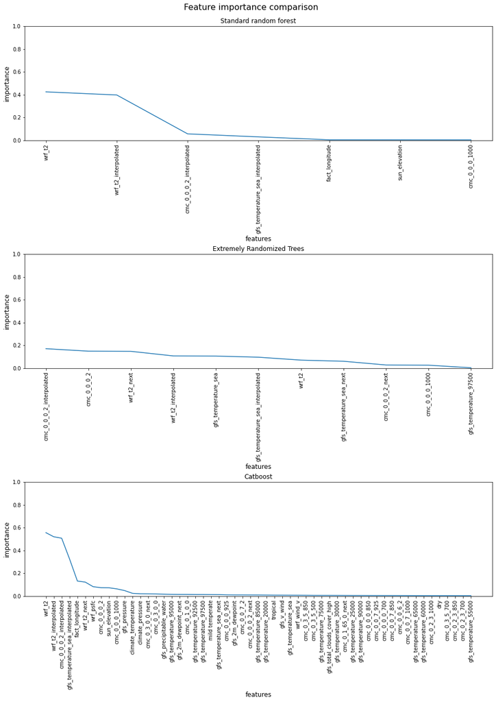

```python
IMPORTANCE = 3e-3

def draw_temp_plot(ax, model, model_title):
    try:
        feature_flag = np.where(model.feature_importances_ > IMPORTANCE)
        feature = np.array([model.feature_names_in_[feature_flag], model.feature_importances_[feature_flag]])
        feature =  feature[:, feature[1, :].argsort()][:, ::-1]
        ax.plot(feature[0], feature[1])

    except AttributeError:
        feature = np.array([np.array(model.feature_names_), model.feature_importances_])
        feature[1] = feature[1].astype(np.float64) / np.linalg.norm(feature[1].astype(np.float64))
        feature_flag = np.where(feature[1].astype(np.float64) > IMPORTANCE)
        feature = feature[:, feature_flag[0]]
        feature = feature[:, feature[1, :].argsort()][:, ::-1]
        ax.plot(feature[0], feature[1].astype(np.float64))

    ax.set_title(model_title)
    ax.set_ylim(0, 1)
    plt.setp(ax.xaxis.get_majorticklabels(), rotation=90)
    ax.set_xlabel("features", fontsize=12)
    ax.set_ylabel("importance", fontsize=12)

f, ax = plt.subplots(3, 1, figsize=(16, 20))
f.suptitle('Feature importance comparison', fontsize=16, y=0.91)
plt.subplots_adjust(wspace=0, hspace=1)

draw_temp_plot(ax[0], standard_random_forest, 'Standard random forest')
draw_temp_plot(ax[1], extr_rand_trees, 'Extremely Randomized Trees')
draw_temp_plot(ax[2], cat, 'Catboost')
```

Наиболее важными для случайного леса оказались предсказания моделей поставщиков. Также он опирается на фактическую долготу и положение солнца.

По сравнению со случайным лесом ERTs по-другому оценивает важность признаков. Если первая модель сильнее опирается на два признака, то вторая модель практически равномерно распределяет веса между большим количеством признаков. Для нее важны предсказания поставщиков, а также информация о температуре в момент, близкий к предсказанию.

На графике веса модели Catboost нормированы. Тем не менее, это позволяет судить о их важности. Эта модель в первую очередь опирается на предсказания российского поставщика. Ей также наиболее важны фактическая долгота, положение солнца, историческая температура, давление. Можно сказать, что catboost присвоил большие веса тем признакам, которые оказались наиболее важными при первичном анализе данных.

```python
import shap
shap.initjs()

def draw_shap(model, X):
    explainer = shap.TreeExplainer(model)
    shap_values = explainer.shap_values(X)
    shap.summary_plot(shap_values, X, plot_type='bar', plot_size=(8, 8))
```

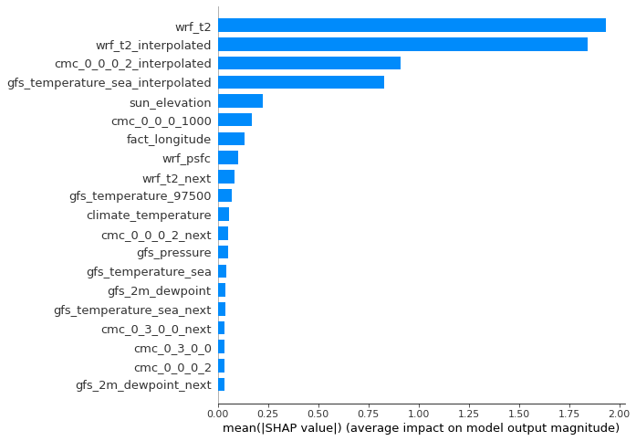

```python
draw_shap(standard_random_forest, df_train.drop('wrf_available', axis=1).iloc[:500])
```

Пакет shap позволяет увидеть дополнительные признаки, которые использует случайный лес. По сравнению с анализом встроенными методами некоторые признаки поменялись местами. Я думаю, что это зависит от размера переданного датафрейма. В связи с его большим размером мне пришлось строить график лишь на первых 500 записях. Самые важные признаки остались прежними.

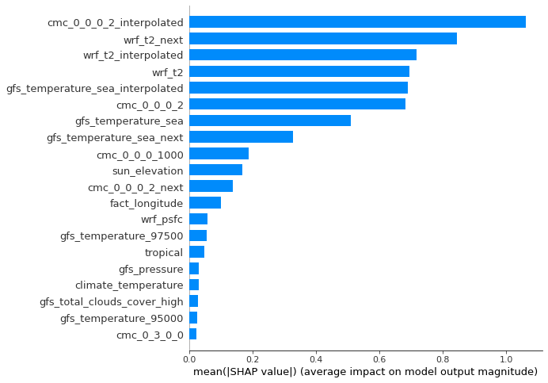

```python
draw_shap(extr_rand_trees, df_train_transformed.iloc[:500])
```

В случае с ERTs различе в положении важности признаков заметно сильнее. Например, shap показывает меньшую важность у прогнозируемой температуры моря. Также становится очевидна важность долготы и положения солнца. На построенном мной графике этого заметно не было.

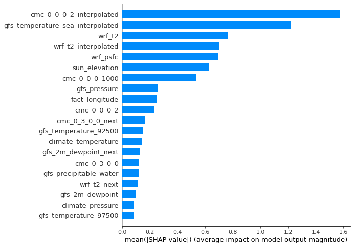

```python
draw_shap(cat, df_train.drop('wrf_available', axis=1).iloc[:500])
```

По отношению к Catboost shap выделяет наиболее важными предсказания уже зарубежных поставщиков, то есть самые важные признаки изменились. Тем не менее, столбцы которые присутствовали в анализе нативными средствами sklearn сохранились.

### Задание 10 (0.5 балл)

В ролике Лена упоминала про ускорение за счет обучения моделей на разных географических регионах. Как первое приближение индикатора принадлежности к тому или иному региону попробуйте использовать имеющуюся категориальную переменную climate.

Удалось ли за счет этого увеличить качество? Можно ли придумать что-то лучшее, чем разбиение по climate?

```python
df_train, df_valid = train_test_frames(dropna=True, climate_one_hot=True)
for climate in df_train.columns[-3:]:
    print('climate={}'.format(climate))
    random_forest = RandomForestRegressor(n_estimators=20, random_state=35)
    grow_forest(random_forest, 'Random forest', df_train.loc[df_train[climate] == 1], df_valid.loc[df_valid[climate] == 1])
```

```
climate=dry
Training time: 0:01:49.461000
Random forest model gives RMSE: 2.36312, TGS: 0.661507
climate=mild temperate
Training time: 0:06:45.491017
Random forest model gives RMSE: 2.05572, TGS: 0.72297
climate=tropical
Training time: 0:01:02.257001
Random forest model gives RMSE: 1.77528, TGS: 0.794327
```

Разбиение по climate дает ощутимый прирост, где *climate=tropical*. Чуть лучше для случайного леса и предсказания для *climate=mild temperate*. Для сухого климата предсказания ухудшились.

Я думаю, стоит обучать модели в зависимости от климата. Для тропического климата лучше обучаться изолированно, а для $climate\in\{mild temperate, dry\}$ данные стоит объединить.

Самым лучшим будет разбиение суши на квадраты определенного размера, пускай и не по 2 км, как делает это Яндекс. Это даст ощутимый прирост и позволит добиться минимального RMSE на предоставленных данных.

## Часть 2

Давайте теперь поставим задачу классификации.

[figure not shown]

```python
train_2018_09.fact_cwsm_class.value_counts(dropna=False)
```

```
0.0     175257
10.0    148256
20.0     81576
11.0     13115
21.0     12004
23.0       170
13.0        36
22.0        16
12.0         6
Name: fact_cwsm_class, dtype: int64
```

```python
(train_2018_09.fact_cwsm_class.astype("int8").isin([0,10,20])).value_counts(normalize=True)
```

```
True     0.941113
False    0.058887
Name: fact_cwsm_class, dtype: float64
```

```python
0.941113 / 0.058887
```

```
15.981676770764345
```

```python
(train_2018_10.fact_cwsm_class.astype("int8").isin([0,10,20])).value_counts(normalize=True)
```

```
True     0.93364
False    0.06636
Name: fact_cwsm_class, dtype: float64
```

Видно, что по объектам шанс 1 к 16, что будут осадки.

Сначала будем решать задачу бинарной классификации

Как будем оценивать эту задачу? Раз у нас классы не сбалансированы, то, согласно, например https://ysda_trove.gitlab.io/ml-handbook/chapters/model_evaluation/intro, метрика accuracy/error_rate нам не подойдёт.

Давайте будем рассматривать

- сбалансированную точность как основную метрику качества
- Как вспомогательные
  - точность предсказания класса 1
  - полноту предсказания класса 1
  - F1-меру

Для начала порог отсечения при принятии решения к какому классу относится предскзание будем брать 0.5

### Задание 11 (0.5 балла)

Постройте baseline решения:

- Dummy Classifier
- дерево решений

По валидационной выборке подберите лучшие параметры

```python
def train_test_cwsm(train, onehot):
    frame = pd.concat([train, onehot], axis=1).drop(['climate', 'wrf_available'], axis=1).dropna()
    target = frame.fact_cwsm_class.replace([0, 10, 20, 11, 12, 13, 21, 22, 23], [0, 0, 0, 1, 1, 1, 1, 1, 1])
    frame = frame.drop(['fact_cwsm_class', 'fact_temperature'], axis=1)
    return frame, target

df_train, cwsm_train = train_test_cwsm(train_2018_09, climate_ohe9)
df_valid, cwsm_valid = train_test_cwsm(train_2018_10, climate_ohe10)
df_test, cwsm_test = train_test_cwsm(train_2018_11, climate_ohe11)
```

```python
from sklearn.metrics import balanced_accuracy_score, precision_score, recall_score, f1_score

def classify(model, model_title, df_train, df_valid):
    start_time = datetime.now()
    classifier = model.fit(df_train, cwsm_train)
    print('Training time:', datetime.now() - start_time)

    y_pred = model.predict(df_valid)
    b_acc = balanced_accuracy_score(cwsm_valid, y_pred)
    precision = precision_score(cwsm_valid, y_pred, average='weighted')
    recall = recall_score(cwsm_valid, y_pred, average='weighted')
    f1 = f1_score(cwsm_valid, y_pred, average='weighted')
    print("{} model gives balanced accuracy: {:.6}, precision: {:.6}, recall: {:.6}, f1: {:.6}".format(
        model_title, b_acc, precision, recall, f1))
```

```python
from sklearn.dummy import DummyClassifier
from sklearn.tree import DecisionTreeClassifier
```

```python
dc = DummyClassifier(strategy='stratified', random_state=35)
classify(dc, 'Dummy classifier', df_train, df_valid)

decision_tree = DecisionTreeClassifier(random_state=35)
classify(decision_tree, 'Decision tree', df_train, df_valid)
```

```
Training time: 0:00:00.214504
Dummy classifier model gives balanced accuracy: 0.500006, precision: 0.876536, recall: 0.883695, f1: 0.88008
Training time: 0:02:16.523761
Decision tree model gives balanced accuracy: 0.618134, precision: 0.899409, recall: 0.845545, f1: 0.869134
```

Видимо DummyClassifier вообще не признает класс 1 (выпадение осадков). Об этом можно судить по *balanced accuracy=0.5*.

Дерево решений же пытается предсказать наступление осадков честно. Однако такая задача прогнозирования является более сложной, чем предсказание погоды, этим и объясняется низкий accuracy.

```python
classifier = DecisionTreeClassifier(random_state=35)

param_grid = {'max_depth': np.arange(15, 22, 3),
             'min_samples_leaf': np.arange(1, 3)}

grid = GridSearchCV(classifier, param_grid, cv=2, scoring='balanced_accuracy').fit(df_train, cwsm_train)
grid.best_params_
```

```
{'max_depth': 21, 'min_samples_leaf': 1}
```

```python
grid.best_score_
```

```
0.6207154742961161
```

### Задание 12 (2.5 балла)

- обучите RF-ERT на оригинальных признаках
- обучите RF-ERT поверх квантизации, которая была лучшей в задачи регрессии
- обучите catboost
- сравните качество по рассмотренным ранее метрикам (основной и дополнительным)
- сравните важности принаков
  - встроенными методами
  - при помщи пакета shap

```python
from sklearn.ensemble import RandomForestClassifier, ExtraTreesClassifier
from sklearn.tree import ExtraTreeClassifier
```

```python
random_forest = RandomForestClassifier(n_estimators=20, max_depth=20, random_state=35)
classify(random_forest, 'Random forest', df_train, df_valid)

extr_rand_trees = ExtraTreesClassifier(n_estimators=20, max_depth=20, random_state=35)
classify(extr_rand_trees, 'Extremely Randomized Trees', df_train, df_valid)

extr_rand_tree = ExtraTreeClassifier(random_state=35)
classify(extr_rand_tree, 'Extremely Randomized Tree', df_train, df_valid)
```

```
Training time: 0:01:54.834014
Random forest model gives balanced accuracy: 0.58399, precision: 0.915998, recall: 0.934507, f1: 0.919509
Training time: 0:00:30.493004
Extremely Randomized Trees model gives balanced accuracy: 0.559959, precision: 0.916958, recall: 0.935992, f1: 0.916457
Training time: 0:00:02.215000
Extremely Randomized Tree model gives balanced accuracy: 0.609442, precision: 0.900683, recall: 0.88593, f1: 0.892899
```

По основной метрике обученные модели уступают дереву решений. Однако они показывают более высокие дополнительные метрики, что говорит о том, что класс выпадения осадков ими выделяется лучше. В некоторой степени высокий recall можно считать более полезной метрикой, т.к. для наблюдателя остаться дома и не попасть под дождь, который не наступит - лучше, чем довериться прогнозу и попасть под дождь, который не удалось предсказать.

```python
cq = CatboostQuantizer(32, 'Uniform').fit(df_train)

df_train_transformed = cq.transform(df_train)
df_valid_transformed = cq.transform(df_valid)

random_forest_t = RandomForestClassifier(n_estimators=20, max_depth=20, random_state=35)
classify(random_forest_t, 'Random forest', df_train_transformed, df_valid_transformed)

extr_rand_trees_t = ExtraTreesClassifier(n_estimators=20, max_depth=20, random_state=35)
classify(extr_rand_trees_t, 'Extremely Randomized Trees', df_train_transformed, df_valid_transformed)

extr_rand_tree_t = ExtraTreeClassifier(random_state=35)
classify(extr_rand_tree_t, 'Extremely Randomized Tree', df_train_transformed, df_valid_transformed)
```

```
Training time: 0:00:55.169030
Random forest model gives balanced accuracy: 0.572413, precision: 0.914906, recall: 0.9346, f1: 0.917763
Training time: 0:00:30.286015
Extremely Randomized Trees model gives balanced accuracy: 0.557223, precision: 0.915925, recall: 0.935633, f1: 0.915755
Training time: 0:00:02.158999
Extremely Randomized Tree model gives balanced accuracy: 0.601081, precision: 0.898945, recall: 0.884811, f1: 0.891524
```

В случае со случайным лесом квантизация дает ускорение во времени обучения в два раза. При этом результаты метрик остались прежними.

```python
from catboost import CatBoostClassifier

start_time = datetime.now()
cat = CatBoostClassifier(random_state=35).fit(df_train, cwsm_train, verbose=False, plot=False)
print('Training time:', datetime.now() - start_time)
```

```
Training time: 0:02:17.502315
```

```python
y_pred = cat.predict(df_valid)
b_acc = balanced_accuracy_score(cwsm_valid, y_pred)
precision = precision_score(cwsm_valid, y_pred, average='weighted')
recall = recall_score(cwsm_valid, y_pred, average='weighted')
f1 = f1_score(cwsm_valid, y_pred, average='weighted')
print("Catboost gives balanced accuracy: {:.6}, precision: {:.6}, recall: {:.6}, f1: {:.6}".format(
    b_acc, precision, recall, f1))
```

```
Catboost gives balanced accuracy: 0.600947, precision: 0.920062, recall: 0.936183, f1: 0.923004
```

Catboost дает самые высокие дополнительные метрики, но *balanced accuracy* опередить решающее дерево ему не удалось.

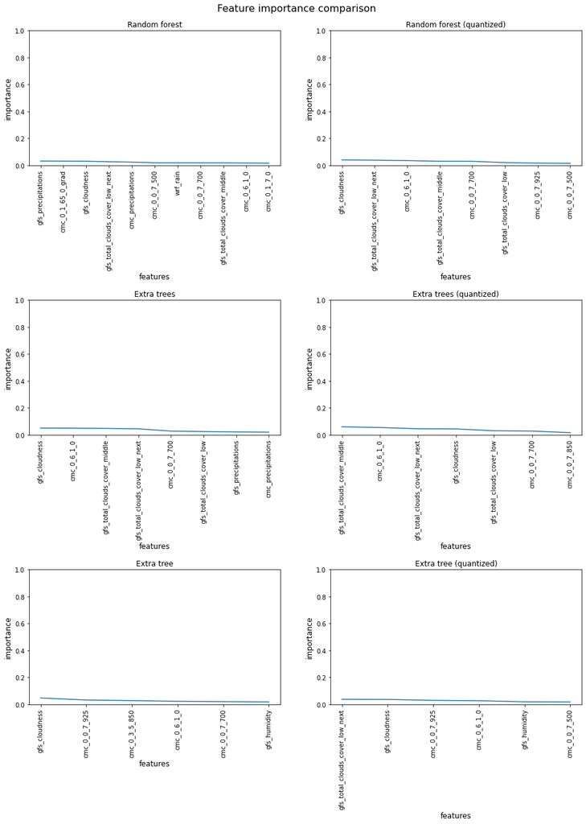

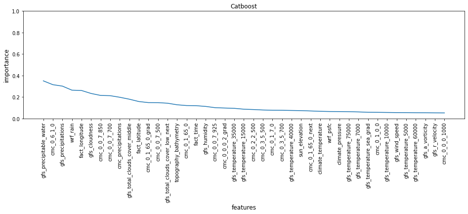

```python
IMPORTANCE = 0.015

def draw_temp_plot(ax, model, model_title):
    try:
        feature_flag = np.where(model.feature_importances_ > IMPORTANCE)
        feature = np.array([model.feature_names_in_[feature_flag], model.feature_importances_[feature_flag]])
        feature =  feature[:, feature[1, :].argsort()][:, ::-1]
        ax.plot(feature[0], feature[1])
    except AttributeError:
        feature = np.array([np.array(model.feature_names_), model.feature_importances_])
        feature[1] = feature[1].astype(np.float64) / np.linalg.norm(feature[1].astype(np.float64))
        feature_flag = np.where(feature[1].astype(np.float64) > IMPORTANCE)
        feature = feature[:, feature_flag[0]]
        feature = feature[:, feature[1, :].argsort()][:, ::-1]
        ax.plot(feature[0], feature[1].astype(np.float64))

    ax.set_title(model_title)
    ax.set_ylim(0, 1)
    plt.setp(ax.xaxis.get_majorticklabels(), rotation=90)
    ax.set_xlabel("features", fontsize=12)
    ax.set_ylabel("importance", fontsize=12)

f, ax = plt.subplots(3, 2, figsize=(16, 20))
f.suptitle('Feature importance comparison', fontsize=16, y=0.91)
plt.subplots_adjust(hspace=1)

draw_temp_plot(ax[0][0], random_forest, 'Random forest')
draw_temp_plot(ax[0][1], random_forest_t, 'Random forest (quantized)')
draw_temp_plot(ax[1][0], extr_rand_trees, 'Extra trees')
draw_temp_plot(ax[1][1], extr_rand_trees_t, 'Extra trees (quantized)')
draw_temp_plot(ax[2][0], extr_rand_tree, 'Extra tree')
draw_temp_plot(ax[2][1], extr_rand_tree_t, 'Extra tree (quantized)')

IMPORTANCE = 5e-2
f, ax = plt.subplots(1, 1, figsize=(16, 4))
draw_temp_plot(ax, cat, 'Catboost')
```

По графикам важности признаков и их квантизованных аналогов можно сказать, что каждый тип модели сумел выделить для себя набор наиболее важных. В целом, даже графики отдельно взятых моделей оказались похожими. Практически у каждой модели важным признаком является cloudness (и все что связано с облачностью), precipititations (осадки), humidity (влажность). В дополнение catboost выделяет важными фактические координаты места пердсказания.

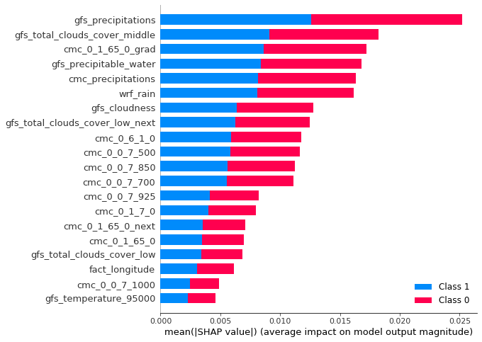

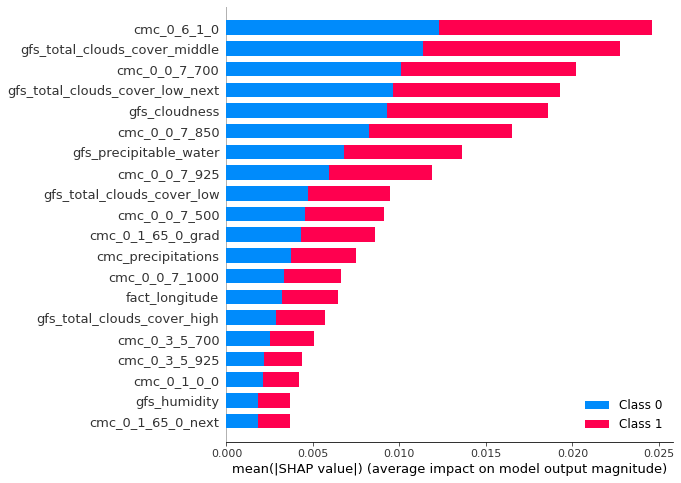

```python
draw_shap(random_forest, df_train.iloc[:100])
draw_shap(random_forest_t, df_train_transformed.iloc[:100])
```

Для случайного леса shap выделяет такие признаки как: облачность, точка росы, осадки, скопление дождя. Можно заметить, что на оригинальных признаках график строится лесенкой, а на квантизованных признаках он более гладкий.

Грфик shap оказывается намного полезнее для оценивания важности призноков, чем стандартные средства sklearn.

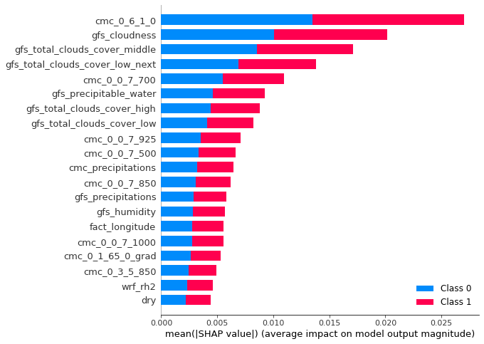

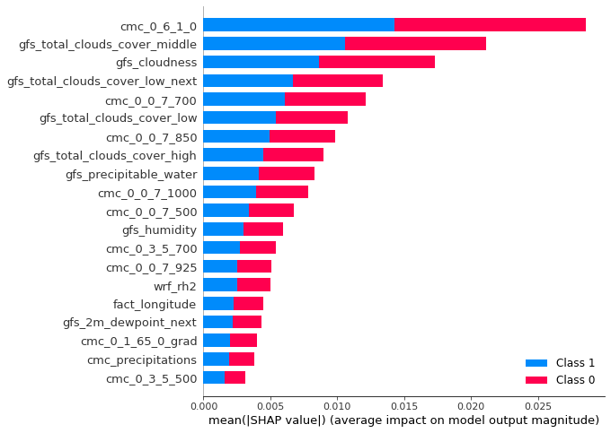

```python
draw_shap(extr_rand_trees, df_train.iloc[:100])
draw_shap(extr_rand_trees_t, df_train_transformed.iloc[:100])
```

ERTs на первое место ставит облачность, затем точку росы. Информация об осадках и влажности явялется наименее важной для данного классификатора.

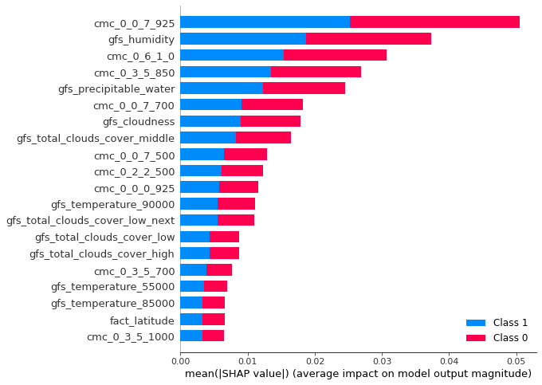

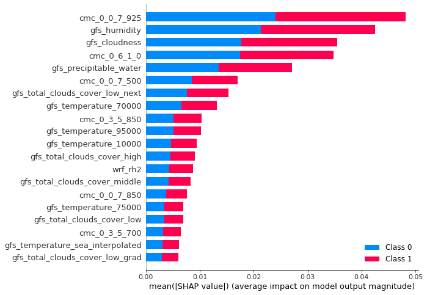

```python
draw_shap(extr_rand_tree, df_train.iloc[:100])
draw_shap(extr_rand_tree_t, df_train_transformed.iloc[:100])
```

ERT на первое место ставит точку росы, влажность, облачность, что разнится с выбором ERTs.

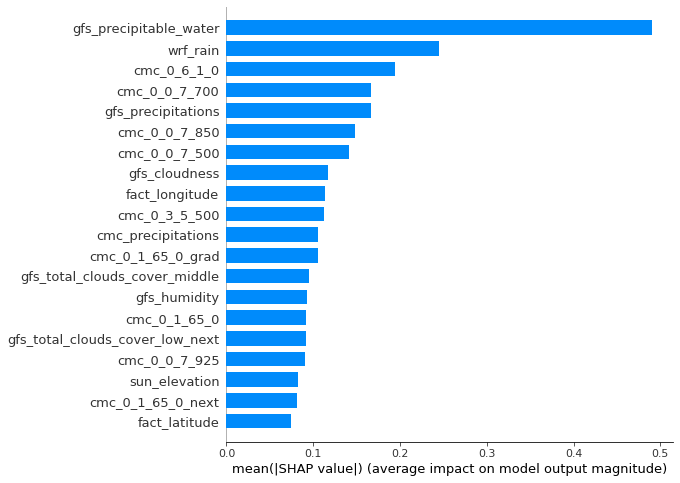

```python
draw_shap(cat, df_train.iloc[:500])
```

### Задание 13. "Протухание модели" (0.5 балла)

Давайте узнаем, происходит ли устаревание ("протухание") модели.

Расмотрите, как модели из регрессионной и классификационной задач предсказывают на 2018_11, 2018_12 и 2019_01.

Происходит ли деградация?

Начнем с задачи классификации.

```python
y_pred = cat.predict(df_test)
b_acc = balanced_accuracy_score(cwsm_test, y_pred)
precision = precision_score(cwsm_test, y_pred, average='weighted')
recall = recall_score(cwsm_test, y_pred, average='weighted')
f1 = f1_score(cwsm_test, y_pred, average='weighted')
print("Catboost model gives balanced accuracy: {:.6}, precision: {:.6}, recall: {:.6}, f1: {:.6}".format(
    b_acc, precision, recall, f1))
```

```
Catboost model gives balanced accuracy: 0.613798, precision: 0.904997, recall: 0.922394, f1: 0.909128
```

```python
temp_corr = train_2018_09.drop(['fact_temperature'], axis=1).corrwith(train_2018_09.fact_temperature)

temp_coor_over_zero = temp_corr[temp_corr > 0].sort_values(ascending=False)
regressor_features = temp_coor_over_zero.index.to_list()

df_train_r = pd.concat([train_2018_09[regressor_features], climate_ohe9], axis=1).dropna().drop('wrf_available', axis=1)
df_test_r = pd.concat([train_2018_11[regressor_features], climate_ohe11], axis=1).dropna().drop('wrf_available', axis=1)

cat = CatBoostRegressor(random_state=35).fit(df_train_r, train_2018_09.fact_temperature[df_train_r.index],
    verbose=False, plot=False)

y_pred = cat.predict(df_test_r)
rmse = mean_squared_error(train_2018_11.fact_temperature[df_test_r.index], y_pred, squared=False)
tgs = two_gradus_score(train_2018_11.fact_temperature[df_test_r.index], y_pred)
print('Catboost gives RMSE: {:.6}, TGS: {:.6}'.format(rmse, tgs))
```

```
Catboost gives RMSE: 2.23299, TGS: 0.705512
```

А вот на предсказании температуры "протухание" регрессионной модели заметно более явно. RMSE ухудшилось с 1.94 до 2.23, а двухградусная метрика упала на 4%.

## Калибровка классификатора

Рассмотрим в задачу, где целевой метрикой является *logloss*. В этом случае необходимо, чтобы классификатор умел предсказывать вероятность принадлежности к классу. К сожалению, на практике часто получается так, что либо классификатор не обладает желаемым свойством (например, SVM без специальных настроек), либо метод *predict_proba* возвращает некорректную вероятность (например, случайный лес возвращает среднее арифметическое вероятностей от каждого дерева, которое не обязано являться корректной вероятностью, подробнее [здесь](http://people.dsv.su.se/~henke/papers/bostrom08b.pdf)).

В этом случае возможны несколько подходов:

- Заменить классификатор на тот, который умеет предсказывать вероятности.
- Воспользоваться калибровкой ответов.

В общем случае первый подход не самый удачный выбор, так как накладывает ограничения на модели, которые можно использовать. Поэтому рассмотрим второй более подробно. По умолчанию SVM может вычислять отступ от заданного объекта до разделяющей гиперплоскости, а не возвращать вероятности. После чего можно обучить преобразование, которое искажает возвращаемое значение в вероятность — это и называется **калибровкой**. Есть несколько известных методов калибровки:

- Калибровка Платта.
- Изотоническая регрессия.

Обратите внимание, что преобразование необходимо обучать на отложенной выборке (то есть классификатор и калибровка должны обучаться на разных подмножествах данных), иначе можно переобучиться. Калибровку можно применять к любым классификаторам (где это разумно и необходимо), особенно к тем, которые не оптимизируют logloss явно.

Для калибровки классификатора в sklearn возможны два подхода:

- взять уже обученный классификатор и откалибровать его на отложенной выборке
- откалибровать по кросс-валидации: калибровочному классификатору передается вся обучающая выборка, которая внутри разбивается на обучающую и калибровочную, после чего происходит усреднение вероятностей по фолдам.

Подробнее об этом можно прочитать в [документации](http://scikit-learn.org/stable/modules/generated/sklearn.calibration.CalibratedClassifierCV.html#sklearn.calibration.CalibratedClassifierCV). Также [здесь](https://jmetzen.github.io/2015-04-14/calibration.html) можно узнать подробности о калибровке в sklearn от автора.

Замечание: выше написано, что SVM по умолчанию не возвращает вероятности. Если же заглянуть в документацию [SVC](http://scikit-learn.org/stable/modules/generated/sklearn.svm.SVC.html), то можно найти параметр *probability*. Если установить его равным *True*, то у такого классификатора можно вызвать метод *predict_proba* и получить оценки вероятностей. В библиотеке реализована калибровка Платта и с классификатором проделывается примерно тоже самое, что было описано выше. Использование этого параметра замедляет процесс обучения, зато позволяет сразу же использовать данный классификатор для оценивания вероятностей. Обратите внимание, что у класса [LinearSVC](http://scikit-learn.org/stable/modules/generated/sklearn.svm.LinearSVC.html) такой опции нет.

### Задание 14 (0.5 балла)

Вспомним, что мы не подбирали порог, по которому классификаторы превращают оценку вероятности принадлежности к первому классу

Давайте оценим, насколько хорошо калиброваны наши классификаторы из Задания 11 на 2018_11

ссылка на главу учебника https://ysda_trove.gitlab.io/ml-handbook/chapters/prob_ML/calibration

https://scikit-learn.org/stable/auto_examples/calibration/plot_calibration_curve.html#sphx-glr-auto-examples-calibration-plot-calibration-curve-py

https://dyakonov.org/2020/03/27/проблема-калибровки-уверенности/

### Задание 15 (1 балл)

Давайте откалибруем классификаторы из задания 11 на 2018_10 и вновь посмотрим на качество их калибровки на 2018_11.

Построим кривые точность-полнота для класса 1 и класса 0 у некалиброванных и калиброванных моделей. Отличаются ли они?

Мы попробовали два типа ансамблей: случайный лес (бэггинг) и градиентный бустинг. Время что-нибудь настекать!

Описание того, как строить ансамбли типа стекинг можно найти по слудующим ссылкам

- На лекции https://lk.yandexdataschool.ru/courses/2021-autumn/7.936-machine-learning-1/classes/7718/
- В учебнике https://ysda_trove.gitlab.io/ml-handbook/chapters/ensembles/intro#стекинг
- В статье https://dyakonov.org/2017/03/10/cтекинг-stacking-и-блендинг-blending/

### Задание 16 (2 балла)

Какие базовые модели можно использовать:

```
* лучшие модели из задания 11
* давайте обучим логистическую регрессию
* по желанию, попробуйте нейросеть
```

Попробуйте брать 2-3 разные базовые модели первого уровня, а в качестве модели второго уровня пропробуйте ERT и catboost.

Весь ансабль должен быть обучен на 2018_09, т.е. нужно применять cross_val_predict.  
Почему так следует делать, можно вспомнить, заглянув в соответствующий раздел учебника  
https://ysda_trove.gitlab.io/ml-handbook/chapters/ensembles/intro

```python
from sklearn.linear_model import LogisticRegression
from sklearn.ensemble import StackingClassifier
from sklearn.model_selection import cross_val_predict, StratifiedKFold

estimators = [
    ('rf', RandomForestClassifier(n_estimators=10, random_state=42)),
    ('logit', LogisticRegression(random_state=35))
]

clf = StackingClassifier(
    estimators=estimators, final_estimator=ExtraTreesClassifier(random_state=35)
)

y_pred = cross_val_predict(clf, df_train, cwsm_train, cv=StratifiedKFold(n_splits=3))
```

```python
b_acc = balanced_accuracy_score(cwsm_train, y_pred)
precision = precision_score(cwsm_train, y_pred, average='weighted')
recall = recall_score(cwsm_train, y_pred, average='weighted')
f1 = f1_score(cwsm_train, y_pred, average='weighted')
print("Stacking classifier model gives balanced accuracy: {:.6}, precision: {:.6}, recall: {:.6}, f1: {:.6}".format(
    b_acc, precision, recall, f1))
```

```
Stacking classifier model gives balanced accuracy: 0.586989, precision: 0.923167, recall: 0.940104, f1: 0.927831
```

Получаем не самое высокое accuracy, но самые высокие дополнительные метрики. Это значит, что наблюдатель с меньшей вероятностью окажется под непредвиденными осадками. Похожая ситуация происходит и при использовании Catboost в качестве модели второго слоя.

```python
clf = StackingClassifier(
    estimators=estimators, final_estimator=CatBoostClassifier(verbose=False, random_state=35)
)

y_pred = cross_val_predict(clf, df_train, cwsm_train, cv=StratifiedKFold(n_splits=3))
```

```python
b_acc = balanced_accuracy_score(cwsm_train, y_pred)
precision = precision_score(cwsm_train, y_pred, average='weighted')
recall = recall_score(cwsm_train, y_pred, average='weighted')
f1 = f1_score(cwsm_train, y_pred, average='weighted')
print("Stacking classifier model gives balanced accuracy: {:.6}, precision: {:.6}, recall: {:.6}, f1: {:.6}".format(
    b_acc, precision, recall, f1))
```

```
Stacking classifier model gives balanced accuracy: 0.571079, precision: 0.931371, recall: 0.945351, f1: 0.928913
```

Так, ансамбли типа стекинг в задаче предсказания осадков стоит использовать с целью уменьшения вероятности оказаться под дождем. Тем не менее, меньший accuracy указывает на то, что модель будет допускать возможность выпадения осадков в большем количестве случаев.